# Canadian Surface Reanalysis - CaSR

**Note**

Please add your comments on this section in [this Google Doc](https://docs.google.com/document/d/1NK32RRhCQ0uRfcpD_u_OcxyP6fZdTxXGrSJ_AIcr3Ls/edit?usp=drive_link).

## Summary Description

The Canadian Surface Reanalysis (CaSR) is a high-resolution atmospheric reanalysis dataset produced by Environment and Climate Change Canada (ECCC). CaSR v3.1 is produced by dynamically downscaling [ECMWF’s ERA5 global reanalysis](https://cds.climate.copernicus.eu/datasets/reanalysis-era5-single-levels) using operational models and configurations of ECCC’s operational weather and environmental prediction system to provide historical, high-resolution climate and weather data over North America, with a focus on Canada. Surface observations of tempererature, humidity, snow depth and precipitation are integrated through the the Canadian Land Data Assimilation System (CaLDAS) coupled with the Canadian Precipitation Analysis (CaPA). CaSR is a consistent and seamless dataset providing the main meteorological variables coherent with in situ surface observations Gasset et al. (2021). Note that the CaSR dataset was previously known as RDRS (Regional Deterministic Reforecast System).

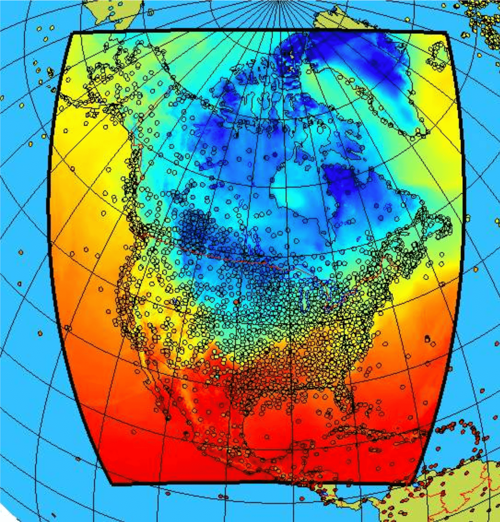

CaSR simulation domain with station locations Gasset et al. (2025)

## Dataset Characteristics

- **Current version:** v3.1
- **Temporal coverage:** 1970–2024
- **Temporal resolution:** Hourly and daily outputs
- **Spatial coverage:** Canada and U.S.
- **Spatial resolution:** ~10 km grid spacing (0.09˚)
- **Data type:** A dynamical downscaling of ERA5 (ERA-Interim for version 2.1) over North and Central America domain using ECCC’s Global Deterministic Reforecast System (GDRS), the global surface model (GEM-Surf) the Regional Deterministic Reforecast System (RDRS), coupled with the CaLDAS surface assimilation system. Environment and Climate Change Canada (ECCC) (2025)
- **Web references:**  
  [ECCC Canadian Surface Reanalysis (CaSR) Web Site](https://hpfx.collab.science.gc.ca/~scar700/rcas-casr/),  
  [Northern Climate Data Report and Inventory (NCDRI) Web Site](https://nordata.physics.utoronto.ca/en/annexes-datasets-descriptions/71-temperature/north-american-precipitation-and-land-surface-reanalysis-regional-deterministic-reforecast-system-rdrs/)
- **Reference publications:**  
  See references below

## Strengths and Limitations

### Key Strengths of CaSR

[output not shown]

### Key Limitations of CaSR

[output not shown]

## Expert Guidance

**Click to toggle section collapse**

The Canadian Surface Reanalysis (CaSR) dataset provides high-resolution, gridded climate data with seamless coverage across North America. CaSR has one of the highest spatial resolutions of gridded observational datasets over Canada and North America and it distinguishes itself from other reanalysis products through the assimilation of precipitation observations through the Canadian Precipitation Analysis (CaPA). It is therefore coherent with in situ observations of precipitation, absolute and dew point temperature and snow depth. The model used in the production includes a representation of lakes, which influence local climate. This feature is visible particularly in the shoulder season temperature fields and influences the thermal surface properties. The CaPA system used to produce the gridded precipitation fields includes strict quality control procedures to avoid the assimilation of biased observations. This includes using wind speed to determine validity of solid precipitation measurements depending on the gauge type and weather station characteristics. Due to the complexity of the prodedure and difficulties with quality control radar data are currently not assimilated. Overall, CaSR was conceptualized for hydrological applications, where high-resolution precipitation and land-surface variables are critical. Gasset et al. (2021)

Temperature biases in CaSR exhibit an annual cycle with larger errors in winter and spring and smaller errors in summer and autumn. When compared to the NRCanMET gridded observations, CaSR shows slightly warmer mean minimum temperatures and slightly colder mean maximum temperatures. As a result, the daily temperature range in CaSR is narrower than in NRCanMET. Air temperature biases are clearly correlated to elevation differences between nearby stations and the corresponding grid elevation. With improvement in the latest version of CaSR spring temperatures are higher and less biased in version 3.1 than in version 2.1. Pixels near water or mixed water/land pixels tend to exhibit a stronger cold bias. Overall, the magnitude of the biases varies by temperature variable and region, emphasizing the need for validation of the dataset at a particular location.

Precipitation in CaSR is generally positively biased, and this bias tends to increase with distance from the assimilated in-situ stations. The dataset is wetter than ERA5-Land, which itself is part of a broader tendency of reanalyses to be too wet. Mountain precipitation is better resolved in CaSR than in ERA5-Land or NRCanMET, owing to its higher spatial resolution. Due to the offline precipitation analysis inconsistencies can arise with other modeled fields such as radiation and humidity.

A study over British Columbia watersheds, confirms CaSR’S persistent cold bias alongside a wet bias. CaSR version 2.1 also shows drying trends in BC watersheds. The dataset proves skillful in capturing spatial mountain patterns and temporal trends. Goswami et al. (2024)

Version 3.1 of CaSR represents a major improvement over version 2.1. It shows better agreement with surface observations across all variables, seasons, and domains. Precipitation performance is similar or slightly improved, and the version includes the additional benefit of a new precipitation partitioning into rainfall and snowfall. Version 3.1 also assimilates up to 1,000 more observations per analysis, particularly improving winter performance in Canada. Gasset et al. (2025)

## Variables available in CaSR

*For details click on variable group to uncollapse*

**Temperature**

- Temperature [˚C]
- Dew point temperature [˚C]

Temperature variables are provided at 1h & 3h frequency and at levels 1.5 m, ~20m, and ~40m. For more details see the respective [table on the CaSR web site](https://hpfx.collab.science.gc.ca/~scar700/rcas-casr/dataset_specifics.html#available_variables).

**Precipitation**

- Quantity of daily precipitation [m]
- Confidence index of daily precipitation
- Quantity of hourly precipitation [m]
- Quantity of ice pellets (liquid water equivalent) [m]
- Quantity of freezing precipitation (liquid water equivalent) [m]
- Quantity of liquid precipitation [m]

Precipitation variables are provided at 1h and 24h frequency at the surface level. Two types of precipitation are available, one forecasted by the model and one generated by the offline precipitation reanalysis system. For more details see the [section on precipitation fields](https://hpfx.collab.science.gc.ca/~scar700/rcas-casr/dataset_specifics.html#champs_precip) and the [data variables table](https://hpfx.collab.science.gc.ca/~scar700/rcas-casr/dataset_specifics.html#available_variables) on the CaSR web site.

**Wind**

- U-component of the wind (along the grid X axis) [kts]
- V-component of the wind (along the grid Y axis) [kts]
- Corrected U-component of the wind (along West-East direction) [kts]
- Corrected V-component of the wind (along South-North direction) [kts]
- Wind Modulus [kts]
- Meteorologial Wind direction [degree]

Wind variables are provided at 1h frequency and at levels 10m, ~20m, and ~40m. For more details see the respective [table on the CaSR web site](https://hpfx.collab.science.gc.ca/~scar700/rcas-casr/dataset_specifics.html#available_variables).

**Humidity**

- Relative humidity [%]
- Specific humidity [kg/kg]

Humidity variables are provided at 1h frequency and at levels 1.5 m, ~20m, and ~40m. For more details see the respective [table on the CaSR web site](https://hpfx.collab.science.gc.ca/~scar700/rcas-casr/dataset_specifics.html#available_variables).

**Radiation**

- Downward solar flux [W/m<sup>2</sup>]
- Surface incoming infrared flux [W/m<sup>2</sup>]

Radiation variables are provided at 1h frequency at the surface level. For more details see the respective [table on the CaSR web site](https://hpfx.collab.science.gc.ca/~scar700/rcas-casr/dataset_specifics.html#available_variables).

**Snow**

- Water equivalent of snow depth over land subgrid tile [kg/m<sup>2</sup>]
- Snow depth over land subgrid tile [cm]

Snow variables are provided at 24h frequency at the surface level. For more details see the respective [table on the CaSR web site](https://hpfx.collab.science.gc.ca/~scar700/rcas-casr/dataset_specifics.html#available_variables).

**Other Meteorological Variables**

- Surface pressure [mb]
- Sea level pressure [mb]
- Geopotential height [dam]

These meteorological variables are provided at 1h frequency and (depending on variable) at surface level, ~20m, and ~40m. For more details see the respective [table on the CaSR web site](https://hpfx.collab.science.gc.ca/~scar700/rcas-casr/dataset_specifics.html#available_variables).

## Data Access

CaSR data can be downloaded from the CaSPAr platform, the PAVICS platform or ECCC’s high-performance computer GPSC-C. The CaSR website provides [instructions for these different download options](https://hpfx.collab.science.gc.ca/~scar700/rcas-casr/download.html). To avoid downloading the very large dataset in it’s entirety PAVICS allows partial/regional extraction and provides [a tutorial to do so](https://pavics-sdi.readthedocs.io/en/latest/notebooks/CaSR_basic.html). With a free PAVICS user account the Jupyter notebook with the Python code in the tutorial can be [directly used on PAVICS](https://pavics.ouranos.ca/jupyter/hub/user-redirect/lab/tree/tutorial-notebooks/CaSR_basic.ipynb).

## References

Environment and Climate Change Canada (ECCC), 2025. Canadian surface reanalysis (CaSR) - data specifics [WWW Document]. ECCC web site. URL https://hpfx.collab.science.gc.ca/~scar700/rcas-casr/dataset_specifics.html (accessed 5.11.2025).

Gasset, N., Fortin, V., Dimitrijevic, M., Carrera, M., Bilodeau, B., Muncaster, R., Gaborit, É., Roy, G., Pentcheva, N., Bulat, M., Wang, X., Pavlovic, R., Lespinas, F., Khedhaouiria, D., Mai, J., 2021. A 10 km north american precipitation and land-surface reanalysis based on the GEM atmospheric model. Hydrology and Earth System Sciences 25, 4917–4945. https://doi.org/10.5194/hess-25-4917-2021

Gasset, N., Khedhaouiria, D., Fortin, V., Lauer, A., Dimitrijevic, M., Bulat, M., Pentcheva, N., Wang, X., Muncaster, R., 2025. [Réanalyse canadienne de surface (RCaS-CaSR) version 3.1 d’environnement et changement climatique canada (ECCC)](https://www.ouranos.ca/sites/default/files/2025-02/03_Gasset_Nicolas_Jour_1_Salle2_session9_16h.pdf).

Goswami, U.P., Déry, S.J., and, V.F., 2024. Performance evaluation of high-resolution reanalysis datasets over north-central british columbia. Atmosphere-Ocean 62, 222–242. https://doi.org/10.1080/07055900.2024.2308878

Khedhaouiria, G., D., Bulat, M., 2025? Canadian surface reanalysis (CaSR) v3: ECCC hourly 0.1° surface reanalysis across north america. in preparation.